# Final Fundamentos 2020

## 3. Bayesiana y regularización

Lee el ejempo *2.7 Informative prior distribution for cancer rates* del libro [Bayesian Data Analysis](http://www.stat.columbia.edu/~gelman/book/BDA3.pdf) (página 46).

En el siguiente ejercicio harás algo similar al ejemplo anterior, en este caso con el modelo Beta-Binomial.

Los datos *pew_research_center_june_elect_wknd_data.dta* tienen información de encuestas realizadas durante la campaña presidencial 2008 de EUA.

```r
library(tidyverse)
library(arm)
```

```r
library(ggplot2)
library(dplyr)
library(readr)
library(foreign)
library(usdata)
poll_data <- foreign::read.dta("data/pew_research_center_june_elect_wknd_data.dta")
poll_data$ideo = as.character(poll_data$ideo)
poll_data[is.na(poll_data$ideo),]$ideo = 0
poll_data[poll_data$ideo=="very conservative",]$ideo = 2
poll_data[poll_data$ideo=="conservative",]$ideo = 1
poll_data[poll_data$ideo=="moderate",]$ideo = 0
poll_data[poll_data$ideo=="dk/refused",]$ideo = 0
poll_data[poll_data$ideo=="liberal",]$ideo = -1
poll_data[poll_data$ideo=="very liberal",]$ideo = -2

poll_data<- poll_data %>% filter(state != 'hawaii' & state != 'washington dc')
poll_data <- poll_data%>%mutate(very_liberal = poll_data$ideo == -2)
table(poll_data$ideo == -2)
```

```
##
## FALSE  TRUE
## 29675  1463
```

- Estima el porcentaje de la población de cada estado (excluyendo Alaska, Hawai, y DC) que se considera *very liberal*, utilizando el estimador de máxima verosimilitud.

```r
# Hacemos la limpieza de los datos
# Una vez hecha la limpieza generamos un nuevo DF en el cual seleccionamos por estado a los votantes "very_liberal"
# Secalcula el porcentaje de Very_Liberal por estado
df_vl <- poll_data %>%group_by(state)  %>% summarise(very_liberal_pct = sum(very_liberal)/n(), samplesize = n(), very_liberal = sum(very_liberal))# %>% select(state, very_liberal_pct, samplesize)
```

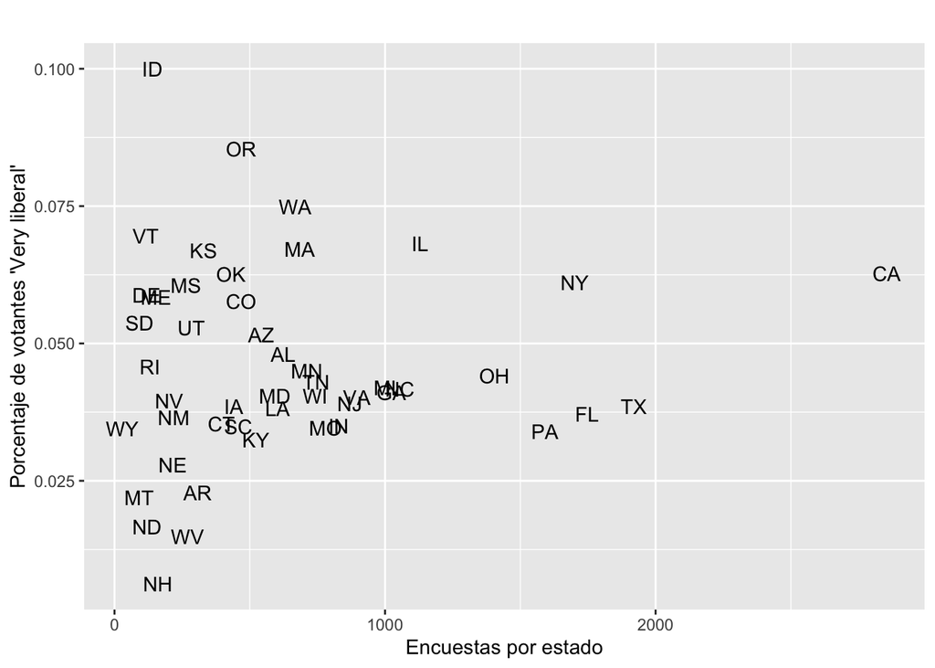

```r
df_vl$state <- df_vl$state%>%as.character()

#df_vl[df_vl$state == "washington dc",]$state = "district of columbia"

#alas <- data.frame(state = c("alaska"), very_liberal_pct = c(0), samplesize = c(0))
#df_vl <- rbind(df_vl,alas)

df_vl<- df_vl %>% filter(state != 'hawaii' & state != 'washington dc')

df_vl$state = state2abbr(toupper(df_vl$state))

p <- ggplot(df_vl, aes(y=very_liberal_pct,  x=samplesize))
p <- p + geom_text(aes(label=state)) +
  labs(title="",
       x = "Encuestas por estado",
       y = "Porcentaje de votantes 'Very liberal'")
p
```

```r
#df_vl_cho <- df_vl[,c(1,2)]
#names(df_vl_cho) = c("region","value")
#state_choropleth(df_vl_cho, title = "Proporcion de gente 'Very Liberal'")
####
election08 = read_csv("http://www.stat.columbia.edu/~gelman/surveys.course/2008ElectionResult.csv")
obama_pct_st <- election08 %>% dplyr::select(state, vote_Obama_pct)

obama_pct_st$state <- obama_pct_st$state%>%tolower
obama_pct_st$state = state2abbr(toupper(obama_pct_st$state))
obama_pct_st<- obama_pct_st %>% filter(state != 'hawaii' & state != 'district of columbia' & state != 'alaska')

df_vl <- df_vl %>% inner_join(obama_pct_st)
```

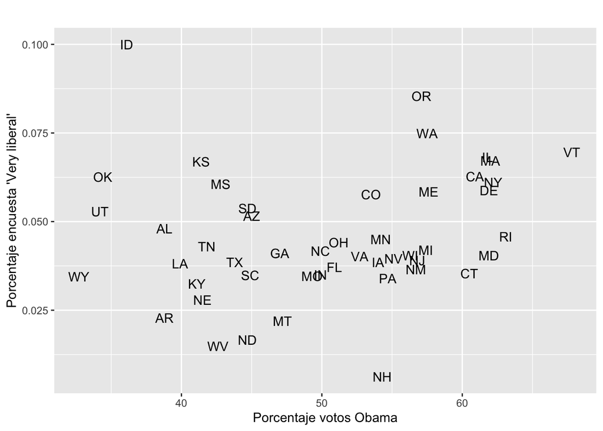

```r
q <- ggplot(df_vl, aes(y=very_liberal_pct,  x=vote_Obama_pct))
q + geom_text(aes(label=state)) +
  labs(title="",
       x = "Porcentaje votos Obama",
       y = "Porcentaje encuesta 'Very liberal'")
```

- Grafica en el eje *x* el número de encuestas para cada estado y en el eje *y* la estimación de máxima verosimilitud. ¿Qué observas?

#### Se Observa que demasiada incertidumbe en los estados que hicieron muy pocas encuestas, por lo tanto no deberiamos de considerarlos.

- Grafica en el eje *x* el porcentaje de votos que obtuvo Obama en la elección para cada estado y en el eje *y* la estimación de máxima verosimilitud. ¿Qué observas? (usa los datos *2008ElectionResult.csv*)
- Estima el mismo porcentaje usando inferencia bayesiana, en particular la familia conjugada binomial-beta. Deberás estimar la proporción de manera independiente para cada estado, sin embargo, utilizarás la misma inicial a lo largo de todos.
  - Para elegir los parámetros $\alpha$, $\beta$ de la incial considera la media y varianza de la distribución predictiva posterior (que en este caso tiene distribución [Beta-Binomial](https://en.wikipedia.org/wiki/Beta-binomial_distribution)) y empata la media y varianza observadas a sus valores observados para después depejar $\alpha$ y $\beta$ (puedes usar [Wolfram alpha](https://www.wolframalpha.com/) para resolver).
  - Utiliza la media posterior de cada estado como estimador puntual y repite las gráficas del inciso anterior.